# Звіт до лабораторної роботи №1

Варакута Олександр КІ-24-1

2025-06-02

# 1. Тема:

**Основи роботи з Git. Налаштування Git-GitHub середовища.**

## 2 Мета:

Швидкий старт для роботи із системою контролю версій (СКВ) Git та віддаленим репозиторієм GitHub.

# 3.Постановка завдання

1. Створити акаунт на GitHub і налаштувати доступ до нього (через SSH або HTTPS).
2. Створити на GitHub репозиторій **matstat_-Varakuta-** **Public**
   - із файлом `README.md`, що містить:

   ```
   У цьому каталозі містяться лабораторні роботи з математичної статистики студента групи <КІ-24-1> <Варакути Олександра Олеговича>»
   ```

3. Клонувати репозиторій на комп’ютер.
4. Створити звіт з усіма кроками та скріншотами.
5. Надати відповіді на контрольні запитання.

# 4. Хід роботи

### Створення акаунту на GitHub

Створено акаунт на [GitHub](https://github.com/Olexandr0120)

### Створення нового репозиторію

Репозиторій **matstat_-Varakuta-**створено.

[figure not shown]

Додано файл `README.md` із вмістом, як у завданні.

[figure not shown]

### Клонування репозиторію на комп’ютер

```bash
git clone https://github.com/Olexandr0120/matstat_-Varakuta-.git
```

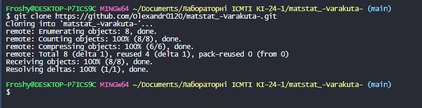

### Налаштування Git на локальній машині

```bash
git config --global user.name "<Варакута Олександ Олегович>"
git config --global user.email "<varakyta.sasha14@gmail.com>"
git config --global core.editor "notepad"
```

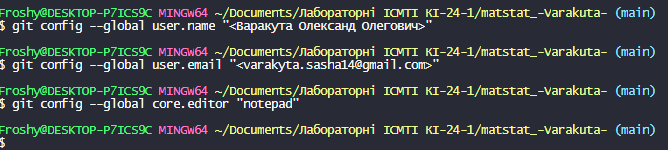

### Перевірка налаштувань

```bash
git config -l
```

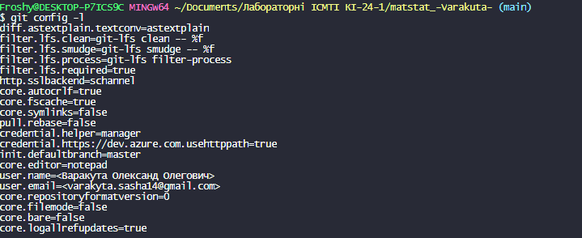

### Додавання змін

```bash
echo "Це тестовий файл" > lab1.txt
git add lab1.txt
git commit -m "Додав тестовий файл"
```

### Надсилання змін на GitHub

```bash
git push origin main
```

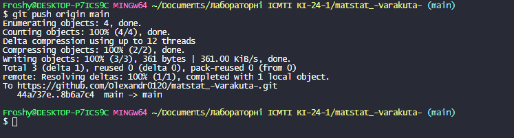

# 5. Висновки

- Ознайомлено з принципами роботи Git і GitHub.
- Створено віддалений репозиторій і зв’язано його з локальним.
- Навченося основним командам Git.

# 6. Контрольні запитання

**1. Що таке система контроля версій і для чого вона призначена?**  
СКВ дозволяє відслідковувати зміни у файлах, зберігати історію, повертатися до попередніх версій та працювати командно.

**2. Відмінність СКВ SVN і Git:**  
SVN — централізована, Git — розподілена (усі мають повну копію репозиторію).

**3. Що робить команда `git add .`?**  
Додає всі файли в поточному каталозі до індексу.

**4. Що робить команда `git commit`?**  
Фіксує зміни в історії репозиторію.

**5. Яка команда завантажує локальні зміни на GitHub?**

```bash
git push origin main
```